# Group 1: Matching

`5765 - Specialization: Economic and Social Policy`

# Introduction

This tutorial is based on a [Matching-Tutorial by Simon Ejdemyr](https://github.com/sejdemyr/ecls) using [US data](https://www.childandfamilydataarchive.org/cfda/archives/cfda/studies/4075) on student achievements (math test scores) and school types (public and catholic) for young pupils from the turn of the millennium. More specifically we are interested the effect of going to a Catholic school, as opposed to a public school, on student achievement. As we will see in the pre-analysis, students from Catholic schools are on average different from students who attend public school. Thus, they are not directly comparable and assuming selection on observable we perform matching to generate a sample in which treatment (in our case going to a catholic school) is independent of covariates.

**Code Sources:** [Tutorial by Ejdemyr](https://github.com/sejdemyr/ecls), MatchIt

**Data Source:** [childandfamilydataarchive.org](https://www.childandfamilydataarchive.org/cfda/archives/cfda/studies/4075)

First, there are some steps that the R code works on your computer. Second, we will briefly repeat the main intuition and options when using matching methods. Third, some data wrangling is necessary to prepare the data and after that we will, finally, start with the actual tutorial which is structured as follows:

1. Pre-analysis
2. Propensity score estimation
3. Region of common support
4. Matching Magic
5. Checking balance
6. Estimating treatment effects

## Setup

For the R code (as an Rmd file) to work you need to

1. Download the data
2. Change the working directory
3. Install required packages

### 1. Download the data

- Go to https://www.childandfamilydataarchive.org/cfda/archives/cfda/studies/4075
- Click on ‘Download’, choose ‘SPSS’, read and accept the Terms of Use
- Annoying but necessary: create an account (using Google, LinkedIn or from scratch)
- Then you should be prompted to a page that automatically downloads the ZIP-file (57 MB)
- Unzip the downloaded zip file. In it, there’s a file called ‘04075-0001-Data.por’. Place this file directly in your working directory of R

### 2. Change the working directory

Change the working directory in the setup chunk of the Rmd file `knitr::opts_knit$set(root.dir = "insert/working/directory")`

### 3. Install required packages

install required packages if there not installed yet using `install.packages()` and load them in your current library

```r
library(tidyverse)   # welcome to the dark side
library(haven)       # to import spss files
library(sjmisc)      # data and variable transformation
library(MatchIt)     # matching fun
```

For R there are two main packages for matching:

- `MatchIt`, which will be used in this tutorial and
- `Matching`

## Matching

### Intuition

General intuition of matching:

1. for each treated observation, ﬁnd a non-treated observation that is as similar as possible
2. compare outcomes between treated and non-treated groups

> “The goal of matching is to produce covariate balance, that is, for the distributions of covariates in the two groups to be approximately equal to each other, as they would be in a successful randomized experiment.” ([MatchIt Vignette](https://cran.r-project.org/web/packages/MatchIt/vignettes/MatchIt.html))

### Options

Options when using matching:

- *Choice of covariates:* Variables that influence the treatment likelihood (propensity score) and the outcome AND that cannot be influenced by the treatment
- *Similarity measure:* coveriate vector (multi-dimensional) OR single index based on coveriates (one-dimensional, e.g. prpensity score)
- *Methods for choosing control observations (Number of matches per treated unit):* Nearest-neighbour (1:1 matching), M-nearest-neighbour (1:M matching), Kernel (1:all matching)
- *Distance measure:* e.g. Euclidean distance, Mahalanobis (covariance-normalized) distance ect.
- *Replacement*: with OR w/o replacement
- *Causal estimation method:* simple comparison of means, OLS, DiD etc.

Since there are many subjective choices in matching setup reporting different matching methods is a good idea to reduce researcher bias.

# Data Wrangling

from ecls-clean.R of [Tutorial by Ejdemyr](https://github.com/sejdemyr/ecls)

- An R script for processing data from the Early Childhood Longitudinal Study.
- The output is saved to ‘data-processed/ecls.csv’.

## Read data

Note: this may take a little while. If you’re getting a “can’t allocate memory” error, install the latest version of `haven` and restart R.

```r
dta <- read_por('data-raw/04075-0001-Data.por')
names(dta) <- tolower(names(dta))
```

## Convert variables

Convert variables of interest to character/numeric

```r
vars_chrs <- c("childid",
               "l5cathol",
               "l5public",
               "r5race",
               "w3povrty",
               "w3daded",
               "w3momed",
               "w3inccat",
               "p5fstamp")

vars_nums <- c("w3momscr",
               "w3dadscr",
               "p5numpla",
               "p5hmage",
               "p5hdage",
               "c5r2mtsc")

dta <- dta %>%
  mutate_at(vars(one_of(vars_chrs)), funs(as.character(to_label(.)))) %>%
  mutate_at(vars(one_of(vars_nums)), funs(as.numeric(as.character(to_label(.)))))
```

Select variables of interest

```r
dta <- dta %>% dplyr::select(one_of(c(vars_chrs, vars_nums)))
```

## Create dummies & recoding

Create catholic dummy: Filter down to catholic and public school students and create a dummy for catholic

```r
dta <- dta %>%
  filter(l5cathol == 'YES' | l5public == 'YES') %>%
  mutate(catholic = if_else(l5cathol == 'YES', 1, 0))
```

Create race dummies

```r
dta <- dta %>%
  mutate(race_white = if_else(r5race == 'WHITE, NON-HISPANIC', 1, 0),
         race_black = if_else(r5race == 'BLACK OR AFRICAN AMERICAN, NON-HISPANIC', 1, 0),
         race_hispanic = if_else(r5race %in% c('HISPANIC, RACE SPECIFIED', 'HISPANIC, RACE NOT SPECIFIED'), 1, 0),
         race_asian = if_else(r5race == 'ASIAN', 1, 0))
```

Set scores of 0 or below on occupational prestige scores, number of places lived, and mother’s/father’s age to NA

```r
dta <- dta %>%
  mutate_at(vars(w3momscr, w3dadscr, p5numpla, p5hmage, p5hdage),
            funs(ifelse(. <= 0, NA, .)))
```

Create poverty and food stamp dummies

```r
dta <- dta %>%
  mutate(w3povrty = if_else(w3povrty == 'BELOW POVERTY THRESHOLD', 1, 0),
         p5fstamp = if_else(p5fstamp == 'YES', 1, if_else(p5fstamp == 'NO', 0, as.double(NA))))
```

Create dummies for high school or below (grouping ‘some college’ as above)

```r
hs_cats <- c('8TH GRADE OR BELOW', '9TH - 12TH GRADE', 'HIGH SCHOOL DIPLOMA/EQUIVALENT',
             'VOC/TECH PROGRAM')
dta <- dta %>%
  mutate_at(vars(w3daded, w3momed),
            funs('hsb' = if_else(. %in% hs_cats, 1,
                          if_else(. == 'NOT APPLICABLE', as.double(NA), 0))))
```

Recode income categories to numeric: Income categories are set at their midvalue. 5000 or less is set to 5000; 200,001 or more is set to 200,001.

```r
dta <- dta %>%
  mutate(w3inccat = if_else(w3inccat == '$5,000 OR LESS', '$5,000 TO $5,000',
                            if_else(w3inccat == '$200,001 OR MORE', '$200,001 TO $200,001', w3inccat)))

convert_income <- function(s) {                              # function for converting income
  split_mat <- str_split_fixed(s, " TO ", n = 2)
  split_mat <- gsub('\\$|,', '', split_mat)
  (as.numeric(split_mat[, 1]) + as.numeric(split_mat[, 2])) / 2
}

test <- unique(dta$w3inccat)                                 # test function
data.frame(test, convert_income(test))
```

```
##                    test convert_income.test.
## 1    $50,001 TO $75,000              62500.5
## 2    $40,001 TO $50,000              45000.5
## 3                  <NA>                   NA
## 4   $75,001 TO $100,000              87500.5
## 5  $100,001 TO $200,000             150000.5
## 6     $5,001 TO $10,000               7500.5
## 7    $15,001 TO $20,000              17500.5
## 8    $30,001 TO $35,000              32500.5
## 9    $35,001 TO $40,000              37500.5
## 10   $20,001 TO $25,000              22500.5
## 11     $5,000 TO $5,000               5000.0
## 12   $10,001 TO $15,000              12500.5
## 13   $25,001 TO $30,000              27500.5
## 14 $200,001 TO $200,001             200001.0
```

```r
dta <- dta %>% mutate(w3income = convert_income(w3inccat))   # finally, convert income
```

## Standardized math score

Clean math t score and create a standardized score

```r
dta <- dta %>%
  mutate(c5r2mtsc = if_else(c5r2mtsc <= 0, as.double(NA), as.numeric(c5r2mtsc)),
         c5r2mtsc_std = (c5r2mtsc - mean(c5r2mtsc, na.rm = T)) / sd(c5r2mtsc, na.rm = T))
```

Remove observations with missing math score

```r
dta <- dta %>% filter(!c5r2mtsc %in% NA)
```

## Select and rename variables

```r
dta <- dta %>% dplyr::select(childid, catholic, race = r5race, race_white, race_black, race_hispanic, race_asian, p5numpla, p5hmage, p5hdage, w3daded, w3momed, w3daded_hsb, w3momed_hsb, w3momscr, w3dadscr, w3inccat, w3income, w3povrty, p5fstamp, test = c5r2mtsc, test_std = c5r2mtsc_std)

write.csv(dta, 'data-processed/ecls.csv', row.names = FALSE)
```

## Next Steps

1. Pre-analysis
2. Estimate propensity score
3. Check and define region of common support (overlap)
4. **Match**
5. Examine covariate balance
6. Estimate treatment effects

# 1. Pre-analysis

Pre-analysis using non-matched data

```r
setwd("~/GitHub/ecls/data-processed")
ecls <- read.csv("ecls.csv")

ecls <- ecls %>% mutate(w3income_1k = w3income / 1000)                    # ????
```

## Difference-in-means: outcome variable

Let’s check the outcome difference on the raw data. The outcome variable is a math test score (standardized so that mean is 0 and standard deviation is one). The explanatory variable is a dummy indicating whether a student went to a catholic (catholic = 1) or public school (catholic = 0).

```r
ecls %>%
  group_by(catholic) %>%
  summarise(n_students = n(),
            mean_test = mean(test_std),
            std_error = sd(test_std) / sqrt(n_students))
```

```
## # A tibble: 2 x 4
##   catholic n_students mean_test std_error
##      <int>      <int>     <dbl>     <dbl>
## 1        0       9568   -0.0306    0.0104
## 2        1       1510    0.194     0.0224
```

The average test score of students of catholic schools is more than 20% of a standard deviation higher than that of public school students. The small standard error indicates that this difference is statistically significant. To make sure let’s perform a t-test.

```r
with(ecls, t.test(test_std ~ catholic))
```

```
##
##  Welch Two Sample t-test
##
## data:  test_std by catholic
## t = -9.1069, df = 2214.5, p-value < 2.2e-16
## alternative hypothesis: true difference in means is not equal to 0
## 95 percent confidence interval:
##  -0.2727988 -0.1761292
## sample estimates:
## mean in group 0 mean in group 1
##     -0.03059583      0.19386817
```

As expected the difference is highly significant.

## Difference-in-means: pre-treatment covariates

The following variables are used:

| name | description | class | values |
| --- | --- | --- | --- |
| race_white | Race | dummy | white (1) |
| w3income | Family income | numeric | in steps of 2.500 |
| p5hmage | Mother’s age | numeric |  |
| p5numpla | Number of places the student has lived for at least 4 months | numeric |  |
| w3momed_hsb | mother’s education level | dummy | high-school or below (1), college or more (0) |

Let’s calculate the mean for each covariate by the treatment status (catholic):

```r
ecls_cov <- c('race_white', 'p5hmage', 'w3income', 'p5numpla', 'w3momed_hsb')

ecls %>%
  group_by(catholic) %>%
  select(one_of(ecls_cov)) %>%
  summarise_all(funs(mean(., na.rm = T)))
```

```
## # A tibble: 2 x 6
##   catholic race_white p5hmage w3income p5numpla w3momed_hsb
##      <int>      <dbl>   <dbl>    <dbl>    <dbl>       <dbl>
## 1        0      0.556    37.6   54889.     1.13       0.464
## 2        1      0.725    39.6   82074.     1.09       0.227
```

The most distinct differences are probably the higher percentage of white students, family income and mother’s education level for students of catholic schools. All of these differences are an indicator that the students are not directly comparable since the mother’s education for example might be correlated with both the probability of treatment (going to a catholic school) and the student achievement (math test score).

Let’s check if the differences are all significant.

```r
ttest <- lapply(ecls_cov, function(v) {
  t.test(ecls[, v] ~ ecls[, 'catholic'])
})

for (i in c(1:5)) {
  print(ttest[[i]]$p.value)
}
```

```
## [1] 1.141333e-39
## [1] 1.581622e-35
## [1] 2.061053e-82
## [1] 2.266892e-05
## [1] 2.08783e-73
```

All differences are statistically significant.

## Formula

```r
formula <- catholic ~ race_white + w3income + p5hmage + p5numpla + w3momed_hsb
```

## Check Initial Imbalance

```r
ecls_nomiss <- ecls %>%  # MatchIt does not allow missing values
  select(test_std, catholic, one_of(ecls_cov)) %>%
  na.omit()
```

No matching yet but just constructing a pre-match matchit object to check balance prior to matching by setting `method = NULL`. With `distance` you set the method to estimate the propensity score. “glm” stands for “generalized linear model”, which implements a logistic regression. Other options include “mahalanobis”, “randomforest” etc. (call `?distance` for all options).

```r
pre_match <- matchit(formula, method = NULL, distance = "glm", data = ecls_nomiss)
dta_pre <- match.data(pre_match)
dim(dta_pre)
```

```
## [1] 9267    9
```

`dta_pre` will be used later to compare initial imbalance to the matched data.

# 2. Propensity score estimation

- Propensity score is the probability of treatment given the covariates (one-dimensional summary)
- outcome variable is a binary variable indicating treatment status
- we use a logit model (probit can also be used)
- any covariate that is related to both the treatment assignment and potential outcomes should be included

```r
m_ps <- glm(formula, family = binomial(), data = ecls)
summary(m_ps)
```

```
##
## Call:
## glm(formula = formula, family = binomial(), data = ecls)
##
## Deviance Residuals:
##     Min       1Q   Median       3Q      Max
## -1.1883  -0.6140  -0.4508  -0.3336   2.5659
##
## Coefficients:
##               Estimate Std. Error z value Pr(>|z|)
## (Intercept) -3.213e+00  2.380e-01 -13.499  < 2e-16 ***
## race_white   3.145e-01  7.009e-02   4.487 7.22e-06 ***
## w3income     7.304e-06  6.495e-07  11.245  < 2e-16 ***
## p5hmage      2.922e-02  5.077e-03   5.755 8.69e-09 ***
## p5numpla    -1.439e-01  9.123e-02  -1.578    0.115
## w3momed_hsb -6.936e-01  7.432e-02  -9.332  < 2e-16 ***
## ---
## Signif. codes:  0 '***' 0.001 '**' 0.01 '*' 0.05 '.' 0.1 ' ' 1
##
## (Dispersion parameter for binomial family taken to be 1)
##
##     Null deviance: 7701.3  on 9266  degrees of freedom
## Residual deviance: 7168.8  on 9261  degrees of freedom
##   (1811 observations deleted due to missingness)
## AIC: 7180.8
##
## Number of Fisher Scoring iterations: 5
```

`predict()` calculates the propensity score which we save in a data frame

```r
prs_df <- data.frame(pr_score = predict(m_ps, type = "response"),
                     catholic = m_ps$model$catholic)
```

# 3. Region of common support

Next, we will check and define region of common support, that is the overlapping distribution of the propensity scores of students attending a catholic on the one hand and a public school on the other hand.

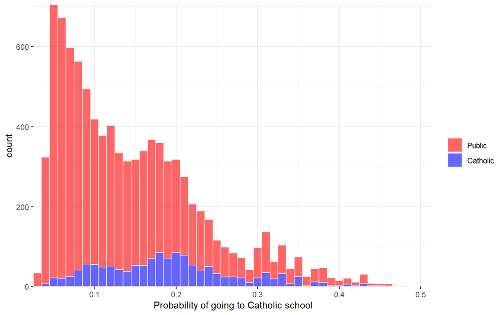

```r
ggplot(prs_df, aes(x = pr_score, fill = factor(catholic))) +
  geom_histogram(binwidth=.01, color = "#FFFFFFAA", alpha = 0.6) +
  xlab("Probability of going to Catholic school") +
  scale_y_continuous(expand = expansion(mult=c(0,0))) +
  scale_x_continuous(expand = expansion(mult=c(0,0))) +
  scale_fill_manual(name = "", values = c("red", "blue"), labels = c("Public", "Catholic")) +
  theme_bw() +
  theme(panel.border = element_blank())
```

```r
prs_df %>% group_by(catholic) %>% summarize(range(pr_score))
```

```
## # A tibble: 4 x 2
## # Groups:   catholic [2]
##   catholic `range(pr_score)`
##      <int>             <dbl>
## 1        0            0.0297
## 2        0            0.506
## 3        1            0.0372
## 4        1            0.477
```

As we can see in the plot and from the summary table both students from catholic and public schools have a similar range of propensity scores.

# 4. Matching Magic

Executing a matching algorithm

## Exact matching

pro: no functional form assumptions are required on either the treatment or outcome model

con: typically many units will be discarded (curse of dimensionality)

```r
x_match <- matchit(formula, method = "exact", distance = "glm", data = ecls_nomiss)
dta_x <- match.data(x_match)
dim(dta_x)
```

```
## [1] 5405    9
```

## Coarsened exact matching

```r
c_match <- matchit(formula, method = "cem", distance = "glm", data = ecls_nomiss)
dta_c <- match.data(x_match)
dim(dta_c)
```

```
## [1] 5405    9
```

## Nearest neighbor propensity score matching

```r
mod_match <- matchit(formula, method = "nearest", data = ecls_nomiss)
dta_m <- match.data(mod_match)
dim(dta_m)
```

```
## [1] 2704   10
```

# 5. Checking balance

## Visually

Ggplot function for visual comparison:

```r
fn_bal <- function(dta, variable) {
  dta$variable <- dta[, variable]
  dta$catholic <- as.factor(dta$catholic)
  ggplot(dta, aes(x = distance, y = variable, color = catholic)) +
    geom_point(alpha = 0.1, size = 1.5) +
    geom_smooth(method = "loess", se = F) +
    xlab("Propensity score") +
    ylab(variable) +
    scale_color_manual(name = "", values = c("red", "blue"), labels = c("Public", "Catholic")) +
    theme_bw() +
    theme(panel.border = element_blank())
}
```

### Before Matching

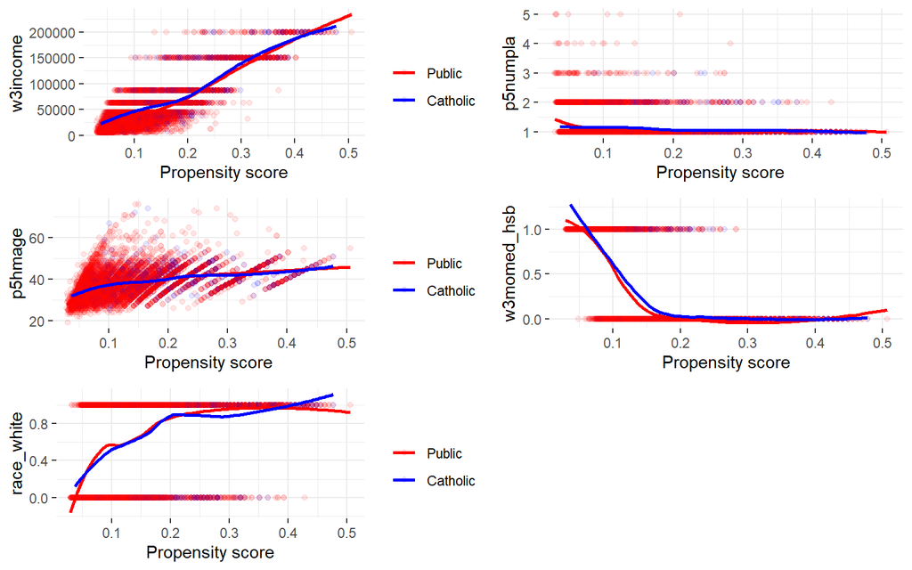

```r
library(gridExtra)
grid.arrange(
   fn_bal(dta_pre, "w3income"),
   fn_bal(dta_pre, "p5numpla") + theme(legend.position = "none"),
   fn_bal(dta_pre, "p5hmage"),
   fn_bal(dta_pre, "w3momed_hsb") + theme(legend.position = "none"),
   fn_bal(dta_pre, "race_white"),
   nrow = 3, widths = c(1, 0.85)
)
```

### Exact Matching

```r
library(gridExtra)
grid.arrange(
   fn_bal(dta_x, "w3income"),
   fn_bal(dta_x, "p5numpla") + theme(legend.position = "none"),
   fn_bal(dta_x, "p5hmage"),
   fn_bal(dta_x, "w3momed_hsb") + theme(legend.position = "none"),
   fn_bal(dta_x, "race_white"),
   nrow = 3, widths = c(1, 0.85)
)
```

```
## Error in FUN(X[[i]], ...): object 'distance' not found
```

### Coarsened Exact Matching

```r
library(gridExtra)
grid.arrange(
   fn_bal(dta_c, "w3income"),
   fn_bal(dta_c, "p5numpla") + theme(legend.position = "none"),
   fn_bal(dta_c, "p5hmage"),
   fn_bal(dta_c, "w3momed_hsb") + theme(legend.position = "none"),
   fn_bal(dta_c, "race_white"),
   nrow = 3, widths = c(1, 0.85)
)
```

```
## Error in FUN(X[[i]], ...): object 'distance' not found
```

### Neigherest neighbor propensity score matching

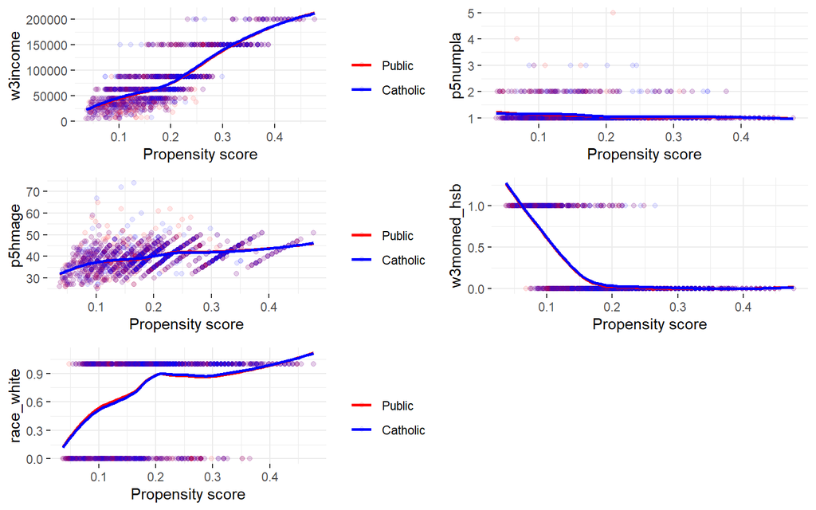

```r
library(gridExtra)
grid.arrange(
   fn_bal(dta_m, "w3income"),
   fn_bal(dta_m, "p5numpla") + theme(legend.position = "none"),
   fn_bal(dta_m, "p5hmage"),
   fn_bal(dta_m, "w3momed_hsb") + theme(legend.position = "none"),
   fn_bal(dta_m, "race_white"),
   nrow = 3, widths = c(1, 0.85)
)
```

## Mean difference

### Before Matching

```r
dta_pre %>%
    group_by(catholic) %>%
    summarise_all(funs(mean))
```

```
## # A tibble: 2 x 9
##   catholic test_std race_white p5hmage w3income p5numpla w3momed_hsb distance
##      <int>    <dbl>      <dbl>   <dbl>    <dbl>    <dbl>       <dbl>    <dbl>
## 1        0   0.0330      0.591    37.6   55485.     1.13       0.461    0.138
## 2        1   0.210       0.741    39.6   82569.     1.09       0.223    0.193
## # ... with 1 more variable: weights <dbl>
```

### Exact Matching

```r
dta_x %>%
    group_by(catholic) %>%
    summarise_all(funs(mean))
```

```
## # A tibble: 2 x 9
##   catholic test_std race_white p5hmage w3income p5numpla w3momed_hsb weights
##      <int>    <dbl>      <dbl>   <dbl>    <dbl>    <dbl>       <dbl>   <dbl>
## 1        0    0.319      0.742    38.6   74464.     1.03       0.276       1
## 2        1    0.219      0.755    39.5   83016.     1.05       0.214       1
## # ... with 1 more variable: subclass <dbl>
```

### Coarsened Exact Matching

```r
dta_c %>%
    group_by(catholic) %>%
    summarise_all(funs(mean))
```

```
## # A tibble: 2 x 9
##   catholic test_std race_white p5hmage w3income p5numpla w3momed_hsb weights
##      <int>    <dbl>      <dbl>   <dbl>    <dbl>    <dbl>       <dbl>   <dbl>
## 1        0    0.319      0.742    38.6   74464.     1.03       0.276       1
## 2        1    0.219      0.755    39.5   83016.     1.05       0.214       1
## # ... with 1 more variable: subclass <dbl>
```

### Neigherest neighbor propensity score matching

```r
dta_m %>%
    group_by(catholic) %>%
    summarise_all(funs(mean))
```

```
## # A tibble: 2 x 10
##   catholic test_std race_white p5hmage w3income p5numpla w3momed_hsb distance
##      <int>    <dbl>      <dbl>   <dbl>    <dbl>    <dbl>       <dbl>    <dbl>
## 1        0    0.359      0.747    39.6   81404.     1.08       0.215    0.193
## 2        1    0.210      0.741    39.6   82569.     1.09       0.223    0.193
## # ... with 2 more variables: weights <dbl>, subclass <dbl>
```

## T-test

### Before Matching

```r
ttest_pre <- lapply(ecls_cov, function(v) {
    t.test(dta_pre[, v] ~ dta_pre$catholic)
})

for (i in c(1:5)) {
  print(ttest_pre[[i]]$p.value)
}
```

```
## [1] 3.421931e-29
## [1] 1.956312e-35
## [1] 4.594728e-79
## [1] 5.525768e-05
## [1] 7.459091e-73
```

### Exact Matching

```r
ttest_x <- lapply(ecls_cov, function(v) {
    t.test(dta_x[, v] ~ dta_x$catholic)
})

for (i in c(1:5)) {
  print(ttest_x[[i]]$p.value)
}
```

```
## [1] 0.36218
## [1] 5.45454e-09
## [1] 6.067037e-09
## [1] 5.586172e-05
## [1] 3.933352e-06
```

### Coarsened Exact Matching

```r
ttest_c <- lapply(ecls_cov, function(v) {
    t.test(dta_c[, v] ~ dta_c$catholic)
})

for (i in c(1:5)) {
  print(ttest_c[[i]]$p.value)
}
```

```
## [1] 0.36218
## [1] 5.45454e-09
## [1] 6.067037e-09
## [1] 5.586172e-05
## [1] 3.933352e-06
```

### Neigherest neighbor propensity score matching

```r
ttest_m <- lapply(ecls_cov, function(v) {
    t.test(dta_m[, v] ~ dta_m$catholic)
})

for (i in c(1:5)) {
  print(ttest_m[[i]]$p.value)
}
```

```
## [1] 0.7245416
## [1] 0.8311005
## [1] 0.5171209
## [1] 0.1806789
## [1] 0.6093401
```

# 6. Estimating treatment effects

OLS

```r
with(dta_m, t.test(test_std ~ catholic))
```

```
##
##  Welch Two Sample t-test
##
## data:  test_std by catholic
## t = 4.2645, df = 2676.3, p-value = 2.073e-05
## alternative hypothesis: true difference in means is not equal to 0
## 95 percent confidence interval:
##  0.08086619 0.21853174
## sample estimates:
## mean in group 0 mean in group 1
##       0.3593668       0.2096679
```

```r
lm_treat1 <- lm(test_std ~ catholic, data = dta_m)
summary(lm_treat1)
```

```
##
## Call:
## lm(formula = test_std ~ catholic, data = dta_m)
##
## Residuals:
##     Min      1Q  Median      3Q     Max
## -3.5110 -0.5670  0.0574  0.6087  2.8456
##
## Coefficients:
##             Estimate Std. Error t value Pr(>|t|)
## (Intercept)  0.35937    0.02482  14.478  < 2e-16 ***
## catholic    -0.14970    0.03510  -4.264 2.07e-05 ***
## ---
## Signif. codes:  0 '***' 0.001 '**' 0.01 '*' 0.05 '.' 0.1 ' ' 1
##
## Residual standard error: 0.9127 on 2702 degrees of freedom
## Multiple R-squared:  0.006686,   Adjusted R-squared:  0.006318
## F-statistic: 18.19 on 1 and 2702 DF,  p-value: 2.072e-05
```

```r
lm_treat2 <- lm(test_std ~ catholic + race_white + p5hmage +
                  I(w3income / 10^3) + p5numpla + w3momed_hsb, data = dta_m)
summary(lm_treat2)
```

```
##
## Call:
## lm(formula = test_std ~ catholic + race_white + p5hmage + I(w3income/10^3) +
##     p5numpla + w3momed_hsb, data = dta_m)
##
## Residuals:
##     Min      1Q  Median      3Q     Max
## -3.5663 -0.5439  0.0439  0.5990  2.7409
##
## Coefficients:
##                    Estimate Std. Error t value Pr(>|t|)
## (Intercept)      -0.4822479  0.1482211  -3.254 0.001154 **
## catholic         -0.1485468  0.0331477  -4.481 7.73e-06 ***
## race_white        0.3097157  0.0385640   8.031 1.43e-15 ***
## p5hmage           0.0119232  0.0032307   3.691 0.000228 ***
## I(w3income/10^3)  0.0031910  0.0003752   8.504  < 2e-16 ***
## p5numpla         -0.0409054  0.0552001  -0.741 0.458734
## w3momed_hsb      -0.3580381  0.0413037  -8.668  < 2e-16 ***
## ---
## Signif. codes:  0 '***' 0.001 '**' 0.01 '*' 0.05 '.' 0.1 ' ' 1
##
## Residual standard error: 0.8613 on 2697 degrees of freedom
## Multiple R-squared:  0.1169, Adjusted R-squared:  0.115
## F-statistic: 59.52 on 6 and 2697 DF,  p-value: < 2.2e-16
```